# Initial Data Exploration

**Documentation:**

- https://www.yelp.com/dataset/documentation/main

**From the documentation the files include the following:**

- business.json - Contains business data including location data, attributes, and categories
- review.json - Contains full review text data including the user_id that wrote the review and the business_id the review is written for.
- user.json - User data including the user's friend mapping and all the metadata associated with the user.
- checkin.json - Checkins on a business.
- tip.json - Tips written by a user on a business. Tips are shorter than reviews and tend to convey quick suggestions.

**Load Libraries**

```python
import matplotlib.pyplot as plt
import json
import numpy as np
import seaborn as sns
import dask
import dask.dataframe as dd
from dask.distributed import Client
from dask import delayed
import dask.bag as db
import pandas as pd
import multiprocessing
import gc

import nltk
from nltk.corpus import stopwords
from nltk.tokenize import word_tokenize
from nltk.stem import WordNetLemmatizer
from nltk.util import bigrams

import re
import string
from wordcloud import WordCloud
# nltk.download('punkt')
# nltk.download('stopwords')
# nltk.download('wordnet')
# nltk.download('omw-1.4')
```

```python
import os
```

## Load Data

```python
data_file = open("Data/yelp_academic_dataset_checkin.json")
data = []
for line in data_file:
    data.append(json.loads(line))
checkin_df = pd.DataFrame(data)
data_file.close()
```

```python
checkin_df.head()
```

|  | business_id | date |
| --- | --- | --- |
| 0 | ---kPU91CF4Lq2-WlRu9Lw | 2020-03-13 21:10:56, 2020-06-02 22:18:06, 2020... |
| 1 | --0iUa4sNDFiZFrAdIWhZQ | 2010-09-13 21:43:09, 2011-05-04 23:08:15, 2011... |
| 2 | --30_8IhuyMHbSOcNWd6DQ | 2013-06-14 23:29:17, 2014-08-13 23:20:22 |
| 3 | --7PUidqRWpRSpXebiyxTg | 2011-02-15 17:12:00, 2011-07-28 02:46:10, 2012... |
| 4 | --7jw19RH9JKXgFohspgQw | 2014-04-21 20:42:11, 2014-04-28 21:04:46, 2014... |

```python
with open("Data/yelp_academic_dataset_business.json", encoding='utf-8') as data_file:
    data = [json.loads(line) for line in data_file]
    for line in data_file:
        data.append(json.loads(line))
    business_df = pd.DataFrame(data)
```

```python
business_df.head()
```

|  | business_id | name | address | city | state | postal_code | latitude | longitude | stars | review_count | is_open | attributes | categories | hours |
| --- | --- | --- | --- | --- | --- | --- | --- | --- | --- | --- | --- | --- | --- | --- |
| 0 | Pns2l4eNsfO8kk83dixA6A | Abby Rappoport, LAC, CMQ | 1616 Chapala St, Ste 2 | Santa Barbara | CA | 93101 | 34.426679 | -119.711197 | 5.0 | 7 | 0 | {'ByAppointmentOnly': 'True'} | Doctors, Traditional Chinese Medicine, Naturop... | None |
| 1 | mpf3x-BjTdTEA3yCZrAYPw | The UPS Store | 87 Grasso Plaza Shopping Center | Affton | MO | 63123 | 38.551126 | -90.335695 | 3.0 | 15 | 1 | {'BusinessAcceptsCreditCards': 'True'} | Shipping Centers, Local Services, Notaries, Ma... | {'Monday': '0:0-0:0', 'Tuesday': '8:0-18:30', ... |
| 2 | tUFrWirKiKi_TAnsVWINQQ | Target | 5255 E Broadway Blvd | Tucson | AZ | 85711 | 32.223236 | -110.880452 | 3.5 | 22 | 0 | {'BikeParking': 'True', 'BusinessAcceptsCredit... | Department Stores, Shopping, Fashion, Home & G... | {'Monday': '8:0-22:0', 'Tuesday': '8:0-22:0', ... |
| 3 | MTSW4McQd7CbVtyjqoe9mw | St Honore Pastries | 935 Race St | Philadelphia | PA | 19107 | 39.955505 | -75.155564 | 4.0 | 80 | 1 | {'RestaurantsDelivery': 'False', 'OutdoorSeati... | Restaurants, Food, Bubble Tea, Coffee & Tea, B... | {'Monday': '7:0-20:0', 'Tuesday': '7:0-20:0', ... |
| 4 | mWMc6_wTdE0EUBKIGXDVfA | Perkiomen Valley Brewery | 101 Walnut St | Green Lane | PA | 18054 | 40.338183 | -75.471659 | 4.5 | 13 | 1 | {'BusinessAcceptsCreditCards': 'True', 'Wheelc... | Brewpubs, Breweries, Food | {'Wednesday': '14:0-22:0', 'Thursday': '16:0-2... |

```python
with open("Data/yelp_academic_dataset_review.json", encoding='utf-8') as data_file:
    data = [json.loads(line) for line in data_file]
    for line in data_file:
        data.append(json.loads(line))
    review_df = pd.DataFrame(data)
```

```python
review_df.head()
```

|  | review_id | user_id | business_id | stars | useful | funny | cool | text | date |
| --- | --- | --- | --- | --- | --- | --- | --- | --- | --- |
| 0 | KU_O5udG6zpxOg-VcAEodg | mh_-eMZ6K5RLWhZyISBhwA | XQfwVwDr-v0ZS3_CbbE5Xw | 3.0 | 0 | 0 | 0 | If you decide to eat here, just be aware it is... | 2018-07-07 22:09:11 |
| 1 | BiTunyQ73aT9WBnpR9DZGw | OyoGAe7OKpv6SyGZT5g77Q | 7ATYjTIgM3jUlt4UM3IypQ | 5.0 | 1 | 0 | 1 | I've taken a lot of spin classes over the year... | 2012-01-03 15:28:18 |
| 2 | saUsX_uimxRlCVr67Z4Jig | 8g_iMtfSiwikVnbP2etR0A | YjUWPpI6HXG530lwP-fb2A | 3.0 | 0 | 0 | 0 | Family diner. Had the buffet. Eclectic assortm... | 2014-02-05 20:30:30 |
| 3 | AqPFMleE6RsU23_auESxiA | _7bHUi9Uuf5__HHc_Q8guQ | kxX2SOes4o-D3ZQBkiMRfA | 5.0 | 1 | 0 | 1 | Wow! Yummy, different, delicious. Our favo... | 2015-01-04 00:01:03 |
| 4 | Sx8TMOWLNuJBWer-0pcmoA | bcjbaE6dDog4jkNY91ncLQ | e4Vwtrqf-wpJfwesgvdgxQ | 4.0 | 1 | 0 | 1 | Cute interior and owner (?) gave us tour of up... | 2017-01-14 20:54:15 |

```python
with open("Data/yelp_academic_dataset_tip.json", encoding='utf-8') as data_file:
    data = [json.loads(line) for line in data_file]
    for line in data_file:
        data.append(json.loads(line))
    tip_df = pd.DataFrame(data)
```

```python
tip_df.head()
```

|  | user_id | business_id | text | date | compliment_count |
| --- | --- | --- | --- | --- | --- |
| 0 | AGNUgVwnZUey3gcPCJ76iw | 3uLgwr0qeCNMjKenHJwPGQ | Avengers time with the ladies. | 2012-05-18 02:17:21 | 0 |
| 1 | NBN4MgHP9D3cw--SnauTkA | QoezRbYQncpRqyrLH6Iqjg | They have lots of good deserts and tasty cuban... | 2013-02-05 18:35:10 | 0 |
| 2 | -copOvldyKh1qr-vzkDEvw | MYoRNLb5chwjQe3c_k37Gg | It's open even when you think it isn't | 2013-08-18 00:56:08 | 0 |
| 3 | FjMQVZjSqY8syIO-53KFKw | hV-bABTK-glh5wj31ps_Jw | Very decent fried chicken | 2017-06-27 23:05:38 | 0 |
| 4 | ld0AperBXk1h6UbqmM80zw | _uN0OudeJ3Zl_tf6nxg5ww | Appetizers.. platter special for lunch | 2012-10-06 19:43:09 | 0 |

```python
with open("Data/yelp_academic_dataset_user.json", encoding='utf-8') as data_file:
    data = [json.loads(line) for line in data_file]
    for line in data_file:
        data.append(json.loads(line))
    user_df = pd.DataFrame(data)
```

```python
user_df.head()
```

|  | user_id | name | review_count | yelping_since | useful | funny | cool | elite | friends | fans | ... | compliment_more | compliment_profile | compliment_cute | compliment_list | compliment_note | compliment_plain | compliment_cool | compliment_funny | compliment_writer | compliment_photos |
| --- | --- | --- | --- | --- | --- | --- | --- | --- | --- | --- | --- | --- | --- | --- | --- | --- | --- | --- | --- | --- | --- |
| 0 | qVc8ODYU5SZjKXVBgXdI7w | Walker | 585 | 2007-01-25 16:47:26 | 7217 | 1259 | 5994 | 2007 | NSCy54eWehBJyZdG2iE84w, pe42u7DcCH2QmI81NX-8qA... | 267 | ... | 65 | 55 | 56 | 18 | 232 | 844 | 467 | 467 | 239 | 180 |
| 1 | j14WgRoU_-2ZE1aw1dXrJg | Daniel | 4333 | 2009-01-25 04:35:42 | 43091 | 13066 | 27281 | 2009,2010,2011,2012,2013,2014,2015,2016,2017,2... | ueRPE0CX75ePGMqOFVj6IQ, 52oH4DrRvzzl8wh5UXyU0A... | 3138 | ... | 264 | 184 | 157 | 251 | 1847 | 7054 | 3131 | 3131 | 1521 | 1946 |
| 2 | 2WnXYQFK0hXEoTxPtV2zvg | Steph | 665 | 2008-07-25 10:41:00 | 2086 | 1010 | 1003 | 2009,2010,2011,2012,2013 | LuO3Bn4f3rlhyHIaNfTlnA, j9B4XdHUhDfTKVecyWQgyA... | 52 | ... | 13 | 10 | 17 | 3 | 66 | 96 | 119 | 119 | 35 | 18 |
| 3 | SZDeASXq7o05mMNLshsdIA | Gwen | 224 | 2005-11-29 04:38:33 | 512 | 330 | 299 | 2009,2010,2011 | enx1vVPnfdNUdPho6PH_wg, 4wOcvMLtU6a9Lslggq74Vg... | 28 | ... | 4 | 1 | 6 | 2 | 12 | 16 | 26 | 26 | 10 | 9 |
| 4 | hA5lMy-EnncsH4JoR-hFGQ | Karen | 79 | 2007-01-05 19:40:59 | 29 | 15 | 7 |  | PBK4q9KEEBHhFvSXCUirIw, 3FWPpM7KU1gXeOM_ZbYMbA... | 1 | ... | 1 | 0 | 0 | 0 | 1 | 1 | 0 | 0 | 0 | 0 |

5 rows × 22 columns

## EDA

### Business Data

**Info and Summary**

```python
business_df.info()
```

```
<class 'pandas.core.frame.DataFrame'>
RangeIndex: 150346 entries, 0 to 150345
Data columns (total 14 columns):
 #   Column        Non-Null Count   Dtype
---  ------        --------------   -----
 0   business_id   150346 non-null  object
 1   name          150346 non-null  object
 2   address       150346 non-null  object
 3   city          150346 non-null  object
 4   state         150346 non-null  object
 5   postal_code   150346 non-null  object
 6   latitude      150346 non-null  float64
 7   longitude     150346 non-null  float64
 8   stars         150346 non-null  float64
 9   review_count  150346 non-null  int64
 10  is_open       150346 non-null  int64
 11  attributes    136602 non-null  object
 12  categories    150243 non-null  object
 13  hours         127123 non-null  object
dtypes: float64(3), int64(2), object(9)
memory usage: 16.1+ MB
```

```python
business_df['city'].value_counts()
```

```
city
Philadelphia      14569
Tucson             9250
Tampa              9050
Indianapolis       7540
Nashville          6971
                  ...
Gentilly              1
pennsauken            1
Hamiltion             1
Newtown square        1
Apollo beach          1
Name: count, Length: 1416, dtype: int64
```

```python
business_df.isnull().sum()
```

```
business_id         0
name                0
address             0
city                0
state               0
postal_code         0
latitude            0
longitude           0
stars               0
review_count        0
is_open             0
attributes      13744
categories        103
hours           23223
dtype: int64
```

```python
business_df.describe()
```

|  | latitude | longitude | stars | review_count | is_open |
| --- | --- | --- | --- | --- | --- |
| count | 150346.000000 | 150346.000000 | 150346.000000 | 150346.000000 | 150346.00000 |
| mean | 36.671150 | -89.357339 | 3.596724 | 44.866561 | 0.79615 |
| std | 5.872759 | 14.918502 | 0.974421 | 121.120136 | 0.40286 |
| min | 27.555127 | -120.095137 | 1.000000 | 5.000000 | 0.00000 |
| 25% | 32.187293 | -90.357810 | 3.000000 | 8.000000 | 1.00000 |
| 50% | 38.777413 | -86.121179 | 3.500000 | 15.000000 | 1.00000 |
| 75% | 39.954036 | -75.421542 | 4.500000 | 37.000000 | 1.00000 |
| max | 53.679197 | -73.200457 | 5.000000 | 7568.000000 | 1.00000 |

- `attributes`, `categories`, and `hours` contain null values
  - Relatively few though, with `categories` barely having any

**Businesses Per City:**

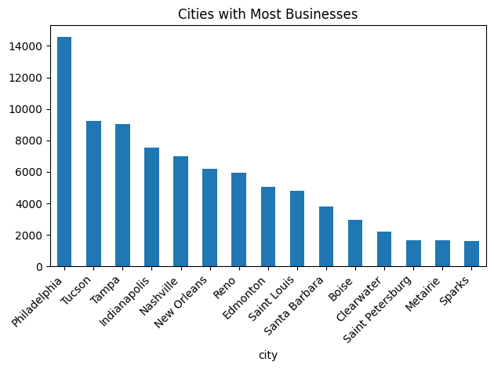

```python
business_per_city = business_df['city'].value_counts()
# business_per_city[:20].plot(kind='bar',
#                   title='Businesses Per City')

ax = business_per_city[:15].plot(kind='bar', title='Cities with Most Businesses')
ax.set_xticklabels(ax.get_xticklabels(), rotation=45, ha='right')  # Angle the x-tick labels
plt.tight_layout()  # Adjust layout to prevent clipping of labels
plt.show()
```

**Frequency of Business Categories:**

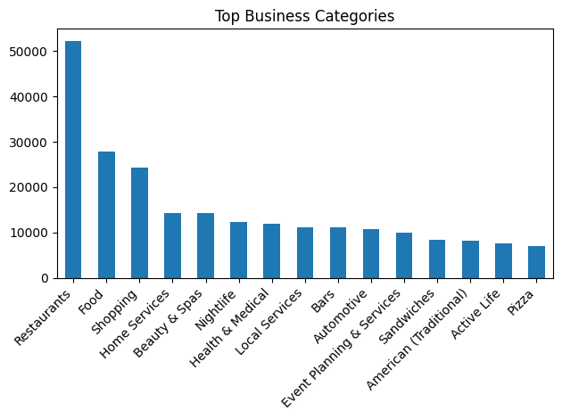

```python
business_categories = business_df['categories']

# Split each string by comma and stack the resulting lists
categories_stacked = business_categories.str.split(', ', expand=True).stack()

# Convert the stacked series to a new DataFrame and reset the index
categories_df = categories_stacked.reset_index(drop=True)

# Display the result
category_counts = categories_df.value_counts()
ax = category_counts[:15].plot(kind='bar', title='Top Business Categories')
ax.set_xticklabels(ax.get_xticklabels(), rotation=45, ha='right')  # Angle the x-tick labels
plt.tight_layout()  # Adjust layout to prevent clipping of labels
plt.show()
```

**Frequency of Business Attributes:**

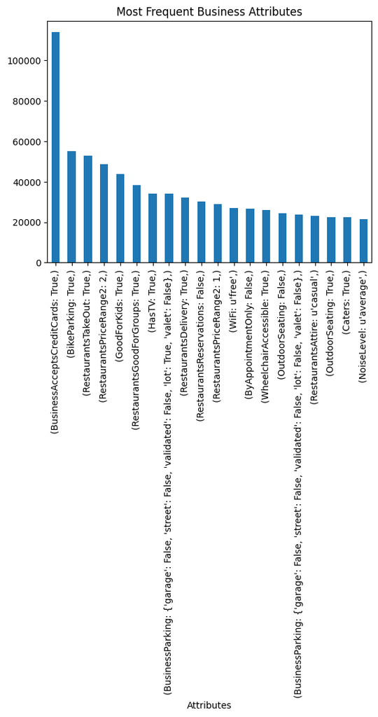

```python
business_attributes = business_df['attributes']

combined_pairs = []

# Iterate over each element in the series
for attributes in business_attributes:
    # Check if the element is a dictionary
    if isinstance(attributes, dict):
        # Extract key-value pairs from the dictionary and append them to the list
        for key, value in attributes.items():
            combined_pairs.append(f"{key}: {value}")

# Create a DataFrame with the combined key-value pairs
result_df = pd.DataFrame({'Attributes': combined_pairs})

attribute_counts = result_df.value_counts()
attribute_counts[:20].plot(kind='bar',
                  title='Most Frequent Business Attributes')
```

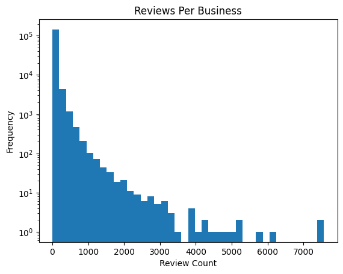

```python
business_df['review_count'].plot(kind='hist', logy=True, bins=40,
                            title='Reviews Per Business',
                            xlabel='Review Count')
```

**Distribution of business ratings**

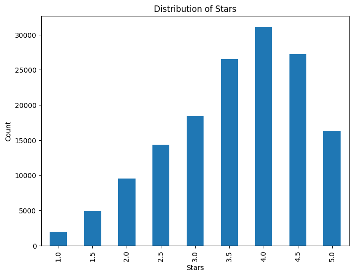

```python
business_stars = business_df['stars'].value_counts()
# Reorder the index from 1 to 5
business_stars_ordered = business_stars.reindex(index=[1.0, 1.5, 2.0, 2.5, 3.0, 3.5, 4.0, 4.5, 5.0])

plt.figure(figsize=(8, 6))
business_stars_ordered.plot(kind='bar',
                           title='Distribution of Stars',
                           xlabel='Stars',
                           ylabel='Count')
```

### User Data

```python
user_df.info()
```

```
<class 'pandas.core.frame.DataFrame'>
RangeIndex: 1987897 entries, 0 to 1987896
Data columns (total 22 columns):
 #   Column              Dtype
---  ------              -----
 0   user_id             object
 1   name                object
 2   review_count        int64
 3   yelping_since       object
 4   useful              int64
 5   funny               int64
 6   cool                int64
 7   elite               object
 8   friends             object
 9   fans                int64
 10  average_stars       float64
 11  compliment_hot      int64
 12  compliment_more     int64
 13  compliment_profile  int64
 14  compliment_cute     int64
 15  compliment_list     int64
 16  compliment_note     int64
 17  compliment_plain    int64
 18  compliment_cool     int64
 19  compliment_funny    int64
 20  compliment_writer   int64
 21  compliment_photos   int64
dtypes: float64(1), int64(16), object(5)
memory usage: 333.7+ MB
```

```python
user_df.describe().T
```

|  | count | mean | std | min | 25% | 50% | 75% | max |
| --- | --- | --- | --- | --- | --- | --- | --- | --- |
| review_count | 1987897.0 | 23.394409 | 82.566992 | 0.0 | 2.0 | 5.00 | 17.00 | 17473.0 |
| useful | 1987897.0 | 42.296335 | 641.480597 | 0.0 | 0.0 | 3.00 | 13.00 | 206296.0 |
| funny | 1987897.0 | 16.970536 | 407.803437 | 0.0 | 0.0 | 0.00 | 2.00 | 185823.0 |
| cool | 1987897.0 | 23.792914 | 565.351295 | 0.0 | 0.0 | 0.00 | 3.00 | 199878.0 |
| fans | 1987897.0 | 1.465740 | 18.130753 | 0.0 | 0.0 | 0.00 | 0.00 | 12497.0 |
| average_stars | 1987897.0 | 3.630494 | 1.183337 | 1.0 | 3.0 | 3.88 | 4.56 | 5.0 |
| compliment_hot | 1987897.0 | 1.807072 | 73.601841 | 0.0 | 0.0 | 0.00 | 0.00 | 25784.0 |
| compliment_more | 1987897.0 | 0.292263 | 12.824667 | 0.0 | 0.0 | 0.00 | 0.00 | 13501.0 |
| compliment_profile | 1987897.0 | 0.179318 | 15.155253 | 0.0 | 0.0 | 0.00 | 0.00 | 14180.0 |
| compliment_cute | 1987897.0 | 0.133649 | 11.356823 | 0.0 | 0.0 | 0.00 | 0.00 | 13654.0 |
| compliment_list | 1987897.0 | 0.063907 | 10.043627 | 0.0 | 0.0 | 0.00 | 0.00 | 12669.0 |
| compliment_note | 1987897.0 | 1.443135 | 60.167900 | 0.0 | 0.0 | 0.00 | 0.00 | 59031.0 |
| compliment_plain | 1987897.0 | 3.011841 | 119.389804 | 0.0 | 0.0 | 0.00 | 0.00 | 101097.0 |
| compliment_cool | 1987897.0 | 2.829308 | 96.663854 | 0.0 | 0.0 | 0.00 | 0.00 | 49967.0 |
| compliment_funny | 1987897.0 | 2.829308 | 96.663854 | 0.0 | 0.0 | 0.00 | 0.00 | 49967.0 |
| compliment_writer | 1987897.0 | 1.056448 | 32.179728 | 0.0 | 0.0 | 0.00 | 0.00 | 15934.0 |
| compliment_photos | 1987897.0 | 1.226859 | 95.157513 | 0.0 | 0.0 | 0.00 | 0.00 | 82630.0 |

**Distribution of Reviews Per User**

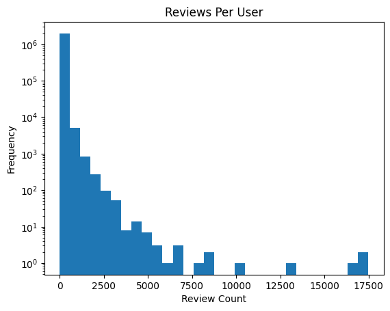

```python
user_df['review_count'].plot(kind='hist', logy=True, bins=30,
                            title='Reviews Per User',
                            xlabel='Review Count')
```

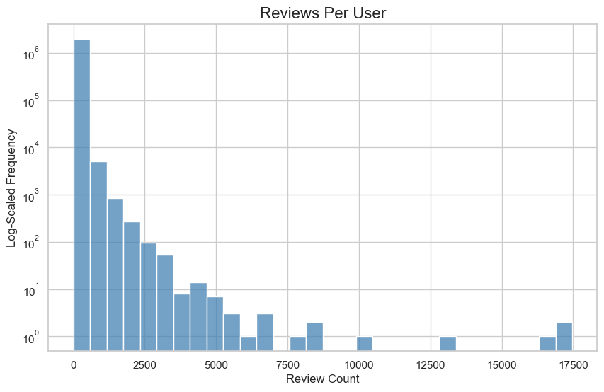

```python
user_df['review_count'] = user_df['review_count'].replace([np.inf, -np.inf], np.nan)
sns.set(style="whitegrid")

# Create the histogram
plt.figure(figsize=(10, 6))
ax = sns.histplot(user_df['review_count'], bins=30, log_scale=(False, True), color='steelblue')
ax.set_title('Reviews Per User', fontsize=16)
ax.set_xlabel('Review Count', fontsize=12)
ax.set_ylabel('Log-Scaled Frequency', fontsize=12)

# Show the plot
plt.show()
```

**Average Stars**

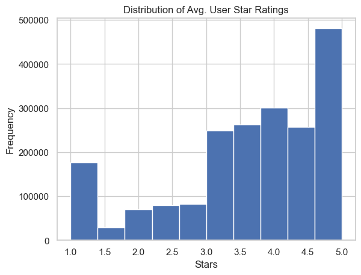

```python
user_df['average_stars'].plot(kind='hist', bins=10,
                            title='Distribution of Avg. User Star Ratings',
                            xlabel='Stars')
```

**User Compliments:**

- Compliments are positive feedback recieved by the user from other users

## Reviews Dataset

```python
review_df.info()
```

[output not shown]

```python
review_df.describe()
```

|  | stars | useful | funny | cool |
| --- | --- | --- | --- | --- |
| count | 6.990280e+06 | 6.990280e+06 | 6.990280e+06 | 6.990280e+06 |
| mean | 3.748584e+00 | 1.184609e+00 | 3.265596e-01 | 4.986175e-01 |
| std | 1.478705e+00 | 3.253767e+00 | 1.688729e+00 | 2.172460e+00 |
| min | 1.000000e+00 | -1.000000e+00 | -1.000000e+00 | -1.000000e+00 |
| 25% | 3.000000e+00 | 0.000000e+00 | 0.000000e+00 | 0.000000e+00 |
| 50% | 4.000000e+00 | 0.000000e+00 | 0.000000e+00 | 0.000000e+00 |
| 75% | 5.000000e+00 | 1.000000e+00 | 0.000000e+00 | 0.000000e+00 |
| max | 5.000000e+00 | 1.182000e+03 | 7.920000e+02 | 4.040000e+02 |

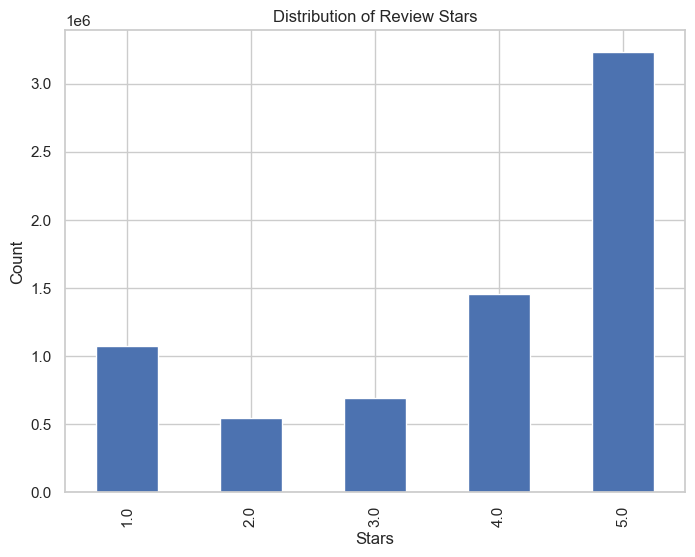

```python
review_stars = review_df['stars'].value_counts()
# Reorder the index from 1 to 5
review_stars_ordered = review_stars.reindex(index=[1.0, 2.0, 3.0, 4.0, 5.0])

plt.figure(figsize=(8, 6))
review_stars_ordered.plot(kind='bar',
                           title='Distribution of Review Stars',
                           xlabel='Stars',
                           ylabel='Count')
```

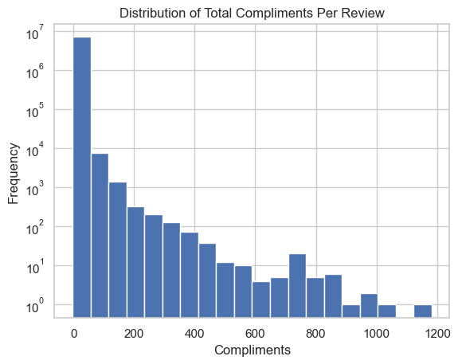

```python
review_df['total_compliments'] = review_df['useful'] + review_df['funny'] + review_df['cool']

review_df['total_compliments'].plot(kind='hist', logy=True, bins=20,
                                   title='Distribution of Total Compliments Per Review',
                                   xlabel='Compliments')
```

```python
review_df['date']
```

```
0          2018-07-07 22:09:11
1          2012-01-03 15:28:18
2          2014-02-05 20:30:30
3          2015-01-04 00:01:03
4          2017-01-14 20:54:15
                  ...
6990275    2014-12-17 21:45:20
6990276    2021-03-31 16:55:10
6990277    2019-12-30 03:56:30
6990278    2022-01-19 18:59:27
6990279    2018-01-02 22:50:47
Name: date, Length: 6990280, dtype: object
```

**Reviews Over Time:**

```python
review_df['date']
review_df[['Date', 'Time']] = review_df['date'].str.split(' ', expand=True)
review_df['Date'] = pd.to_datetime(review_df['Date'])
review_df['Time'] = pd.to_datetime(review_df['Time'], format='%H:%M:%S').dt.time

review_df.head()
```

|  | review_id | user_id | business_id | stars | useful | funny | cool | text | date | total_compliments | Date | Time |
| --- | --- | --- | --- | --- | --- | --- | --- | --- | --- | --- | --- | --- |
| 0 | KU_O5udG6zpxOg-VcAEodg | mh_-eMZ6K5RLWhZyISBhwA | XQfwVwDr-v0ZS3_CbbE5Xw | 3.0 | 0 | 0 | 0 | If you decide to eat here, just be aware it is... | 2018-07-07 22:09:11 | 0 | 2018-07-07 | 22:09:11 |
| 1 | BiTunyQ73aT9WBnpR9DZGw | OyoGAe7OKpv6SyGZT5g77Q | 7ATYjTIgM3jUlt4UM3IypQ | 5.0 | 1 | 0 | 1 | I've taken a lot of spin classes over the year... | 2012-01-03 15:28:18 | 2 | 2012-01-03 | 15:28:18 |
| 2 | saUsX_uimxRlCVr67Z4Jig | 8g_iMtfSiwikVnbP2etR0A | YjUWPpI6HXG530lwP-fb2A | 3.0 | 0 | 0 | 0 | Family diner. Had the buffet. Eclectic assortm... | 2014-02-05 20:30:30 | 0 | 2014-02-05 | 20:30:30 |
| 3 | AqPFMleE6RsU23_auESxiA | _7bHUi9Uuf5__HHc_Q8guQ | kxX2SOes4o-D3ZQBkiMRfA | 5.0 | 1 | 0 | 1 | Wow! Yummy, different, delicious. Our favo... | 2015-01-04 00:01:03 | 2 | 2015-01-04 | 00:01:03 |
| 4 | Sx8TMOWLNuJBWer-0pcmoA | bcjbaE6dDog4jkNY91ncLQ | e4Vwtrqf-wpJfwesgvdgxQ | 4.0 | 1 | 0 | 1 | Cute interior and owner (?) gave us tour of up... | 2017-01-14 20:54:15 | 2 | 2017-01-14 | 20:54:15 |

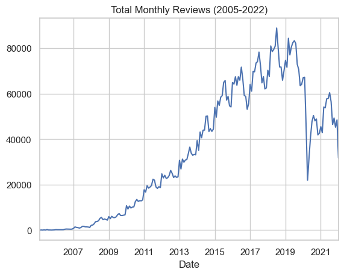

```python
monthly_reviews = review_df['Date'].dt.to_period('M').value_counts().sort_index()
monthly_reviews.plot(title='Total Monthly Reviews (2005-2022)')
```

### Looking at the Review Text

**Function to process text:**

```python
def preprocess_text(text):
    # Lowercase and remove non-alphanumeric characters
    text = text.lower()
    text = re.sub(r'[^\w\s]', '', text)

    # Remove punctuation
    text = text.translate(str.maketrans('', '', string.punctuation))

    # Tokenization
    tokens = word_tokenize(text)

    # Remove stopwords
    stop_words = set(stopwords.words('english'))
    tokens = [word for word in tokens if word not in stop_words]

    # Lemmatizing
    lemmatizer = WordNetLemmatizer()
    tokens = [lemmatizer.lemmatize(token) for token in tokens]

    # Rejoin tokens into a single string
    processed_text = ' '.join(tokens)

    return processed_text
```

```python
def preprocess_text_with_bigrams(text):
    # Lowercase and remove non-alphanumeric characters
    text = text.lower()
    text = re.sub(r'[^\w\s]', '', text)

    # Remove punctuation
    text = text.translate(str.maketrans('', '', string.punctuation))

    # Tokenization
    tokens = word_tokenize(text)

    # Remove stopwords
    stop_words = set(stopwords.words('english'))
    filtered_tokens = [word for word in tokens if word not in stop_words]

    # Lemmatizing
    lemmatizer = WordNetLemmatizer()
    lemmatized_tokens = [lemmatizer.lemmatize(token) for token in filtered_tokens]

    # Generate bigrams and convert bigrams to a single string
    bigram_tokens = [' '.join(bigram) for bigram in bigrams(lemmatized_tokens)]

    # Combine unigrams and bigrams
    all_tokens = lemmatized_tokens + bigram_tokens

    # Rejoin tokens into a single string
    processed_text = ' '.join(all_tokens)

    return processed_text
```

```python
def preprocess_text_just_bigrams(text):
    # Normalize text: lowercase and remove non-alphanumeric characters
    text = re.sub(r'[^\w\s]', '', text.lower())

    # Tokenization
    tokens = word_tokenize(text)

    # Remove stopwords
    stop_words = set(stopwords.words('english'))
    filtered_tokens = [word for word in tokens if word not in stop_words]

    # Lemmatizing
    lemmatizer = WordNetLemmatizer()
    lemmatized_tokens = [lemmatizer.lemmatize(token) for token in filtered_tokens]

    # Generate bigrams
    bigram_tokens = [' '.join(bigram) for bigram in bigrams(lemmatized_tokens)]

    # Rejoin bigram tokens into a single string
    processed_text = ' '.join(bigram_tokens)

    return processed_text
```

**Randomly Sample 1 Million Reviews:**

```python
review_df.head()
```

|  | review_id | user_id | business_id | stars | useful | funny | cool | text | date | total_compliments | Date | Time |
| --- | --- | --- | --- | --- | --- | --- | --- | --- | --- | --- | --- | --- |
| 0 | KU_O5udG6zpxOg-VcAEodg | mh_-eMZ6K5RLWhZyISBhwA | XQfwVwDr-v0ZS3_CbbE5Xw | 3.0 | 0 | 0 | 0 | If you decide to eat here, just be aware it is... | 2018-07-07 22:09:11 | 0 | 2018-07-07 | 22:09:11 |
| 1 | BiTunyQ73aT9WBnpR9DZGw | OyoGAe7OKpv6SyGZT5g77Q | 7ATYjTIgM3jUlt4UM3IypQ | 5.0 | 1 | 0 | 1 | I've taken a lot of spin classes over the year... | 2012-01-03 15:28:18 | 2 | 2012-01-03 | 15:28:18 |
| 2 | saUsX_uimxRlCVr67Z4Jig | 8g_iMtfSiwikVnbP2etR0A | YjUWPpI6HXG530lwP-fb2A | 3.0 | 0 | 0 | 0 | Family diner. Had the buffet. Eclectic assortm... | 2014-02-05 20:30:30 | 0 | 2014-02-05 | 20:30:30 |
| 3 | AqPFMleE6RsU23_auESxiA | _7bHUi9Uuf5__HHc_Q8guQ | kxX2SOes4o-D3ZQBkiMRfA | 5.0 | 1 | 0 | 1 | Wow! Yummy, different, delicious. Our favo... | 2015-01-04 00:01:03 | 2 | 2015-01-04 | 00:01:03 |
| 4 | Sx8TMOWLNuJBWer-0pcmoA | bcjbaE6dDog4jkNY91ncLQ | e4Vwtrqf-wpJfwesgvdgxQ | 4.0 | 1 | 0 | 1 | Cute interior and owner (?) gave us tour of up... | 2017-01-14 20:54:15 | 2 | 2017-01-14 | 20:54:15 |

```python
review_df['text_cleaned_bigrams'] = review_df['text'].apply(lambda x: preprocess_text_just_bigrams(x))
```

```python
review_df.to_pickle("review_df_updated.pkl")
```

```python
review_df = pd.read_pickle("review_df_updated.pkl")
```

```python
review_df = review_df.drop(['text_cleaned_bi'], axis=1)
```

```python
review_df.head()
```

|  | review_id | user_id | business_id | stars | useful | funny | cool | text | date | text_cleaned |
| --- | --- | --- | --- | --- | --- | --- | --- | --- | --- | --- |
| 0 | KU_O5udG6zpxOg-VcAEodg | mh_-eMZ6K5RLWhZyISBhwA | XQfwVwDr-v0ZS3_CbbE5Xw | 3.0 | 0 | 0 | 0 | If you decide to eat here, just be aware it is... | 2018-07-07 22:09:11 | decide eat aware going take 2 hour beginning e... |
| 1 | BiTunyQ73aT9WBnpR9DZGw | OyoGAe7OKpv6SyGZT5g77Q | 7ATYjTIgM3jUlt4UM3IypQ | 5.0 | 1 | 0 | 1 | I've taken a lot of spin classes over the year... | 2012-01-03 15:28:18 | ive taken lot spin class year nothing compare ... |
| 2 | saUsX_uimxRlCVr67Z4Jig | 8g_iMtfSiwikVnbP2etR0A | YjUWPpI6HXG530lwP-fb2A | 3.0 | 0 | 0 | 0 | Family diner. Had the buffet. Eclectic assortm... | 2014-02-05 20:30:30 | family diner buffet eclectic assortment large ... |
| 3 | AqPFMleE6RsU23_auESxiA | _7bHUi9Uuf5__HHc_Q8guQ | kxX2SOes4o-D3ZQBkiMRfA | 5.0 | 1 | 0 | 1 | Wow! Yummy, different, delicious. Our favo... | 2015-01-04 00:01:03 | wow yummy different delicious favorite lamb cu... |
| 4 | Sx8TMOWLNuJBWer-0pcmoA | bcjbaE6dDog4jkNY91ncLQ | e4Vwtrqf-wpJfwesgvdgxQ | 4.0 | 1 | 0 | 1 | Cute interior and owner (?) gave us tour of up... | 2017-01-14 20:54:15 | cute interior owner gave u tour upcoming patio... |

```python
sample = review_df.sample(1000000)
```

```python
sample['text_cleaned_bigrams'] = sample['text'].apply(lambda x: preprocess_text_just_bigrams(x))
```

```python
sample.head()
```

```python
text_concatenated = ' '.join(review_df['text_cleaned'])

wordcloud = WordCloud(width=1200, height=600, background_color='white').generate(text_concatenated)

plt.figure(figsize=(15, 9))
plt.imshow(wordcloud, interpolation='bilinear')
plt.axis('off')
plt.savefig('wordcloud.png', bbox_inches='tight')
plt.show()
```

```python
review_df.head()
```

|  | review_id | user_id | business_id | stars | useful | funny | cool | text | date | text_cleaned | text_cleaned_bi | text_cleaned_bigrams |
| --- | --- | --- | --- | --- | --- | --- | --- | --- | --- | --- | --- | --- |
| 0 | KU_O5udG6zpxOg-VcAEodg | mh_-eMZ6K5RLWhZyISBhwA | XQfwVwDr-v0ZS3_CbbE5Xw | 3.0 | 0 | 0 | 0 | If you decide to eat here, just be aware it is... | 2018-07-07 22:09:11 | decide eat aware going take 2 hour beginning e... | decide eat aware going take 2 hour beginning e... | decide eat eat aware aware going going take ta... |
| 1 | BiTunyQ73aT9WBnpR9DZGw | OyoGAe7OKpv6SyGZT5g77Q | 7ATYjTIgM3jUlt4UM3IypQ | 5.0 | 1 | 0 | 1 | I've taken a lot of spin classes over the year... | 2012-01-03 15:28:18 | ive taken lot spin class year nothing compare ... | ive taken lot spin class year nothing compare ... | ive taken taken lot lot spin spin class class ... |
| 2 | saUsX_uimxRlCVr67Z4Jig | 8g_iMtfSiwikVnbP2etR0A | YjUWPpI6HXG530lwP-fb2A | 3.0 | 0 | 0 | 0 | Family diner. Had the buffet. Eclectic assortm... | 2014-02-05 20:30:30 | family diner buffet eclectic assortment large ... | family diner buffet eclectic assortment large ... | family diner diner buffet buffet eclectic ecle... |
| 3 | AqPFMleE6RsU23_auESxiA | _7bHUi9Uuf5__HHc_Q8guQ | kxX2SOes4o-D3ZQBkiMRfA | 5.0 | 1 | 0 | 1 | Wow! Yummy, different, delicious. Our favo... | 2015-01-04 00:01:03 | wow yummy different delicious favorite lamb cu... | wow yummy different delicious favorite lamb cu... | wow yummy yummy different different delicious ... |
| 4 | Sx8TMOWLNuJBWer-0pcmoA | bcjbaE6dDog4jkNY91ncLQ | e4Vwtrqf-wpJfwesgvdgxQ | 4.0 | 1 | 0 | 1 | Cute interior and owner (?) gave us tour of up... | 2017-01-14 20:54:15 | cute interior owner gave u tour upcoming patio... | cute interior owner gave u tour upcoming patio... | cute interior interior owner owner gave gave u... |

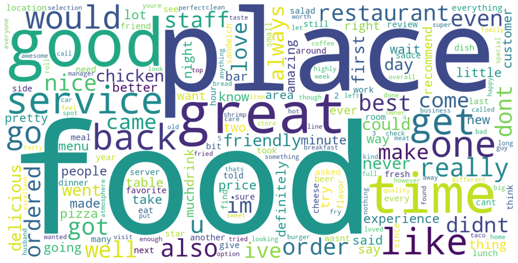

```python
# Function to tokenize and count words in a single partition
def count_words(partition):
    # Tokenize, handle NaN values by replacing them with an empty string
    tokens = partition['text_cleaned'].fillna('').str.split()
    # Flatten the list of lists to a single list of tokens
    flat_list = [item for sublist in tokens.tolist() for item in sublist if item]  # Ensure non-empty items
    # Count occurrences
    counts = {}
    for word in flat_list:
        if word in counts:
            counts[word] += 1
        else:
            counts[word] = 1
    return pd.Series(counts, name='count')

# Load data into a Dask DataFrame
ddf = dd.from_pandas(review_df, npartitions=10)

# Define the metadata as a Series of integers
meta = pd.Series(dtype=int)

# Apply the counting function to each partition
word_series = ddf.map_partitions(count_words, meta=meta)

# Convert series of dictionaries to a DataFrame and perform groupby sum
word_counts_df = word_series.to_frame(name='count')
grouped_word_counts = word_counts_df.groupby(word_counts_df.index).sum()

final_word_counts = grouped_word_counts.compute()

wordcloud = WordCloud(width=1200, height=600, background_color='white').generate_from_frequencies(final_word_counts['count'].to_dict())

plt.figure(figsize=(15, 9))
plt.imshow(wordcloud, interpolation='bilinear')
plt.axis('off')
plt.savefig('wordcloud.png', bbox_inches='tight')
plt.show()
```

```python
# Function to tokenize and count bigrams in a single partition
def count_bigrams(partition):
    # Handle NaN values by replacing them with an empty string
    bigrams = partition['text_cleaned_bigrams'].fillna('').str.split()
    # Flatten the list of lists to a single list of bigrams
    flat_list = [item for sublist in bigrams.tolist() for item in sublist if item]  # Ensure non-empty items
    # Count occurrences
    counts = {}
    for bigram in flat_list:
        if bigram in counts:
            counts[bigram] += 1
        else:
            counts[bigram] = 1
    return pd.Series(counts, name='count')

# Load data into a Dask DataFrame
ddf = dd.from_pandas(review_df, npartitions=10)

# Define the metadata as a Series of integers
meta = pd.Series(dtype=int)

# Apply the counting function to each partition
bigram_series = ddf.map_partitions(count_bigrams, meta=meta)

# Convert series of dictionaries to a DataFrame and perform groupby sum
bigram_counts_df = bigram_series.to_frame(name='count')
grouped_bigram_counts = bigram_counts_df.groupby(bigram_counts_df.index).sum()

final_bigram_counts = grouped_bigram_counts.compute()

wordcloud = WordCloud(width=1200, height=600, background_color='white').generate_from_frequencies(final_bigram_counts['count'].to_dict())

plt.figure(figsize=(15, 9))
plt.imshow(wordcloud, interpolation='bilinear')
plt.axis('off')
plt.savefig('bigram_wordcloud.png', bbox_inches='tight')
plt.show()
```

```python
review_df.head()
```

### Combining Business and Review Datasets

```python
merged_df = pd.merge(review_df, business_df, on='business_id', how='inner')
merged_df.head().T
```

|  | 0 | 1 | 2 | 3 | 4 |
| --- | --- | --- | --- | --- | --- |
| review_id | KU_O5udG6zpxOg-VcAEodg | VJxlBnJmCDIy8DFG0kjSow | S6pQZQocMB1WHMjTRbt77A | WqgTKVqWVHDHjnjEsBvUgg | M0wzFFb7pefOPcxeRVbLag |
| user_id | mh_-eMZ6K5RLWhZyISBhwA | Iaee7y6zdSB3B-kRCo4z1w | ejFxLGqQcWNLdNByJlIhnQ | f7xa0p_1V9lx53iIGN5Sug | dCooFVCk8M1nVaQqcfTL3Q |
| business_id | XQfwVwDr-v0ZS3_CbbE5Xw | XQfwVwDr-v0ZS3_CbbE5Xw | XQfwVwDr-v0ZS3_CbbE5Xw | XQfwVwDr-v0ZS3_CbbE5Xw | XQfwVwDr-v0ZS3_CbbE5Xw |
| stars_x | 3.0 | 2.0 | 4.0 | 3.0 | 2.0 |
| useful | 0 | 0 | 2 | 0 | 0 |
| funny | 0 | 0 | 0 | 0 | 0 |
| cool | 0 | 0 | 1 | 0 | 0 |
| text | If you decide to eat here, just be aware it is... | This is the second time we tried turning point... | The place is cute and the staff was very frien... | We came on a Saturday morning after waiting a ... | Mediocre at best. The decor is very nice, and ... |
| date | 2018-07-07 22:09:11 | 2017-05-13 17:06:55 | 2017-08-08 00:58:18 | 2017-11-19 02:20:23 | 2017-09-09 17:49:47 |
| total_compliments | 0 | 0 | 3 | 0 | 0 |
| Date | 2018-07-07 00:00:00 | 2017-05-13 00:00:00 | 2017-08-08 00:00:00 | 2017-11-19 00:00:00 | 2017-09-09 00:00:00 |
| Time | 22:09:11 | 17:06:55 | 00:58:18 | 02:20:23 | 17:49:47 |
| name | Turning Point of North Wales | Turning Point of North Wales | Turning Point of North Wales | Turning Point of North Wales | Turning Point of North Wales |
| address | 1460 Bethlehem Pike | 1460 Bethlehem Pike | 1460 Bethlehem Pike | 1460 Bethlehem Pike | 1460 Bethlehem Pike |
| city | North Wales | North Wales | North Wales | North Wales | North Wales |
| state | PA | PA | PA | PA | PA |
| postal_code | 19454 | 19454 | 19454 | 19454 | 19454 |
| latitude | 40.210196 | 40.210196 | 40.210196 | 40.210196 | 40.210196 |
| longitude | -75.223639 | -75.223639 | -75.223639 | -75.223639 | -75.223639 |
| stars_y | 3.0 | 3.0 | 3.0 | 3.0 | 3.0 |
| review_count | 169 | 169 | 169 | 169 | 169 |
| is_open | 1 | 1 | 1 | 1 | 1 |
| attributes | {'NoiseLevel': 'u'average'', 'HasTV': 'False',... | {'NoiseLevel': 'u'average'', 'HasTV': 'False',... | {'NoiseLevel': 'u'average'', 'HasTV': 'False',... | {'NoiseLevel': 'u'average'', 'HasTV': 'False',... | {'NoiseLevel': 'u'average'', 'HasTV': 'False',... |
| categories | Restaurants, Breakfast & Brunch, Food, Juice B... | Restaurants, Breakfast & Brunch, Food, Juice B... | Restaurants, Breakfast & Brunch, Food, Juice B... | Restaurants, Breakfast & Brunch, Food, Juice B... | Restaurants, Breakfast & Brunch, Food, Juice B... |
| hours | {'Monday': '7:30-15:0', 'Tuesday': '7:30-15:0'... | {'Monday': '7:30-15:0', 'Tuesday': '7:30-15:0'... | {'Monday': '7:30-15:0', 'Tuesday': '7:30-15:0'... | {'Monday': '7:30-15:0', 'Tuesday': '7:30-15:0'... | {'Monday': '7:30-15:0', 'Tuesday': '7:30-15:0'... |

```python
merged_df['city'].value_counts()
```

```
city
Philadelphia            967552
New Orleans             635364
Tampa                   454889
Nashville               451571
Tucson                  404880
                         ...
Charlack                     5
MIDDLE CITY WEST             5
Huntingdon Valley PA         5
Westhampton                  5
Bridgeton                    5
Name: count, Length: 1416, dtype: int64
```

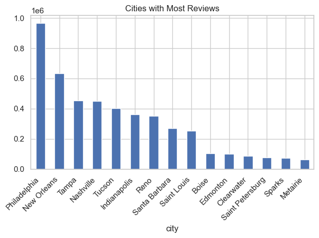

```python
reviews_per_city = merged_df['city'].value_counts()

ax = reviews_per_city[:15].plot(kind='bar', title='Cities with Most Reviews')
ax.set_xticklabels(ax.get_xticklabels(), rotation=45, ha='right')
plt.tight_layout()
plt.show()
```

```python
merged_df['city'].value_counts()
```

```
city
Philadelphia            967552
New Orleans             635364
Tampa                   454889
Nashville               451571
Tucson                  404880
                         ...
Charlack                     5
MIDDLE CITY WEST             5
Huntingdon Valley PA         5
Westhampton                  5
Bridgeton                    5
Name: count, Length: 1416, dtype: int64
```

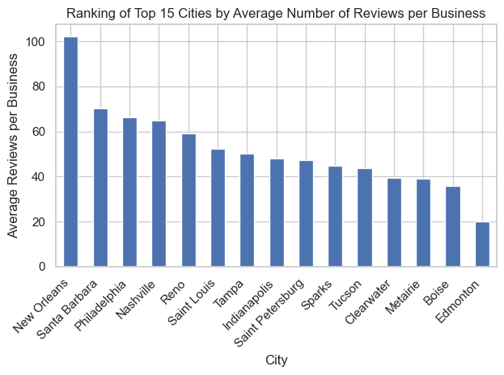

```python
# Calculate the total number of reviews per city
reviews_per_city = merged_df.groupby('city')['review_id'].count()

# Select the top 15 cities based on the number of reviews
top_cities = reviews_per_city.nlargest(15)

# Calculate the total number of businesses per city for the top 15 cities
businesses_per_city = merged_df[merged_df['city'].isin(top_cities.index)].groupby('city')['business_id'].nunique()

# Calculate the average number of reviews per business in each city
avg_reviews_per_business = reviews_per_city / businesses_per_city

# Sort the top cities based on the average number of reviews per business
sorted_top_cities = avg_reviews_per_business[top_cities.index].sort_values(ascending=False)

plt.figure()
sorted_top_cities.plot(kind='bar')
plt.title('Ranking of Top 15 Cities by Average Number of Reviews per Business')
plt.xlabel('City')
plt.ylabel('Average Reviews per Business')
plt.xticks(rotation=45, ha='right')  # Rotate x-tick labels for better readability
plt.tight_layout()
plt.show()
```

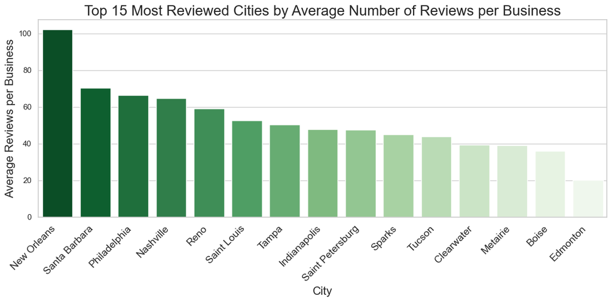

```python
sorted_top_cities_df = sorted_top_cities.reset_index()
sorted_top_cities_df.columns = ['City', 'Average Reviews per Business']

sns.set(style="whitegrid")

plt.figure(figsize=(12, 6))
ax = sns.barplot(x='City', y='Average Reviews per Business', data=sorted_top_cities_df, palette="Greens_r")
ax.set_title('Top 15 Most Reviewed Cities by Average Number of Reviews per Business', fontsize=20)
ax.set_xlabel('City', fontsize=16)
ax.set_ylabel('Average Reviews per Business', fontsize=16)
plt.xticks(rotation=45, ha='right', fontsize=14)

# Show the plot
plt.tight_layout()
plt.show()
```

```python
merged_df[['Date', 'Time']] = merged_df['date'].str.split(' ', expand=True)
merged_df['Date'] = pd.to_datetime(merged_df['Date'])
merged_df['Time'] = pd.to_datetime(merged_df['Time'], format='%H:%M:%S').dt.time

merged_df.head()
```

|  | review_id | user_id | business_id | stars_x | useful | funny | cool | text | date | total_compliments | ... | state | postal_code | latitude | longitude | stars_y | review_count | is_open | attributes | categories | hours |
| --- | --- | --- | --- | --- | --- | --- | --- | --- | --- | --- | --- | --- | --- | --- | --- | --- | --- | --- | --- | --- | --- |
| 0 | KU_O5udG6zpxOg-VcAEodg | mh_-eMZ6K5RLWhZyISBhwA | XQfwVwDr-v0ZS3_CbbE5Xw | 3.0 | 0 | 0 | 0 | If you decide to eat here, just be aware it is... | 2018-07-07 22:09:11 | 0 | ... | PA | 19454 | 40.210196 | -75.223639 | 3.0 | 169 | 1 | {'NoiseLevel': 'u'average'', 'HasTV': 'False',... | Restaurants, Breakfast & Brunch, Food, Juice B... | {'Monday': '7:30-15:0', 'Tuesday': '7:30-15:0'... |
| 1 | VJxlBnJmCDIy8DFG0kjSow | Iaee7y6zdSB3B-kRCo4z1w | XQfwVwDr-v0ZS3_CbbE5Xw | 2.0 | 0 | 0 | 0 | This is the second time we tried turning point... | 2017-05-13 17:06:55 | 0 | ... | PA | 19454 | 40.210196 | -75.223639 | 3.0 | 169 | 1 | {'NoiseLevel': 'u'average'', 'HasTV': 'False',... | Restaurants, Breakfast & Brunch, Food, Juice B... | {'Monday': '7:30-15:0', 'Tuesday': '7:30-15:0'... |
| 2 | S6pQZQocMB1WHMjTRbt77A | ejFxLGqQcWNLdNByJlIhnQ | XQfwVwDr-v0ZS3_CbbE5Xw | 4.0 | 2 | 0 | 1 | The place is cute and the staff was very frien... | 2017-08-08 00:58:18 | 3 | ... | PA | 19454 | 40.210196 | -75.223639 | 3.0 | 169 | 1 | {'NoiseLevel': 'u'average'', 'HasTV': 'False',... | Restaurants, Breakfast & Brunch, Food, Juice B... | {'Monday': '7:30-15:0', 'Tuesday': '7:30-15:0'... |
| 3 | WqgTKVqWVHDHjnjEsBvUgg | f7xa0p_1V9lx53iIGN5Sug | XQfwVwDr-v0ZS3_CbbE5Xw | 3.0 | 0 | 0 | 0 | We came on a Saturday morning after waiting a ... | 2017-11-19 02:20:23 | 0 | ... | PA | 19454 | 40.210196 | -75.223639 | 3.0 | 169 | 1 | {'NoiseLevel': 'u'average'', 'HasTV': 'False',... | Restaurants, Breakfast & Brunch, Food, Juice B... | {'Monday': '7:30-15:0', 'Tuesday': '7:30-15:0'... |
| 4 | M0wzFFb7pefOPcxeRVbLag | dCooFVCk8M1nVaQqcfTL3Q | XQfwVwDr-v0ZS3_CbbE5Xw | 2.0 | 0 | 0 | 0 | Mediocre at best. The decor is very nice, and ... | 2017-09-09 17:49:47 | 0 | ... | PA | 19454 | 40.210196 | -75.223639 | 3.0 | 169 | 1 | {'NoiseLevel': 'u'average'', 'HasTV': 'False',... | Restaurants, Breakfast & Brunch, Food, Juice B... | {'Monday': '7:30-15:0', 'Tuesday': '7:30-15:0'... |

5 rows × 25 columns

```python
new_orleans_df = merged_df[merged_df['city'] == 'New Orleans']
new_orleans_df.head()
```

|  | review_id | user_id | business_id | stars_x | useful | funny | cool | text | date | total_compliments | ... | state | postal_code | latitude | longitude | stars_y | review_count | is_open | attributes | categories | hours |
| --- | --- | --- | --- | --- | --- | --- | --- | --- | --- | --- | --- | --- | --- | --- | --- | --- | --- | --- | --- | --- | --- |
| 564 | Sx8TMOWLNuJBWer-0pcmoA | bcjbaE6dDog4jkNY91ncLQ | e4Vwtrqf-wpJfwesgvdgxQ | 4.0 | 1 | 0 | 1 | Cute interior and owner (?) gave us tour of up... | 2017-01-14 20:54:15 | 2 | ... | LA | 70119 | 29.962102 | -90.087958 | 4.0 | 32 | 0 | {'BusinessParking': '{'garage': False, 'street... | Sandwiches, Beer, Wine & Spirits, Bars, Food, ... | {'Monday': '0:0-0:0', 'Friday': '11:0-17:0', '... |
| 565 | e-1HL9fQFAja1y5gyLUA3w | aG7fzKXqZuG-0vW6NFt8zA | e4Vwtrqf-wpJfwesgvdgxQ | 5.0 | 0 | 0 | 0 | This was my first time here and I will be comi... | 2017-04-30 17:26:37 | 0 | ... | LA | 70119 | 29.962102 | -90.087958 | 4.0 | 32 | 0 | {'BusinessParking': '{'garage': False, 'street... | Sandwiches, Beer, Wine & Spirits, Bars, Food, ... | {'Monday': '0:0-0:0', 'Friday': '11:0-17:0', '... |
| 566 | iGvDv7d44zf61iFrfz06wA | mUIww29FcFs5E67eZsMdvw | e4Vwtrqf-wpJfwesgvdgxQ | 5.0 | 1 | 0 | 0 | We ordered from Melt last night though Waitr. ... | 2018-03-07 12:13:26 | 1 | ... | LA | 70119 | 29.962102 | -90.087958 | 4.0 | 32 | 0 | {'BusinessParking': '{'garage': False, 'street... | Sandwiches, Beer, Wine & Spirits, Bars, Food, ... | {'Monday': '0:0-0:0', 'Friday': '11:0-17:0', '... |
| 567 | eJP8Tv3rKOQMNVj5p_a3iA | uzHh5QORBRg8PkO4yg4rIg | e4Vwtrqf-wpJfwesgvdgxQ | 5.0 | 0 | 0 | 0 | Finally got to check out Melt, and it certainl... | 2018-03-07 01:24:05 | 0 | ... | LA | 70119 | 29.962102 | -90.087958 | 4.0 | 32 | 0 | {'BusinessParking': '{'garage': False, 'street... | Sandwiches, Beer, Wine & Spirits, Bars, Food, ... | {'Monday': '0:0-0:0', 'Friday': '11:0-17:0', '... |
| 568 | CuLAC1anY3h2a4w0Ic8jiQ | 3bRv6h4oOu1lk7N0EEi4DA | e4Vwtrqf-wpJfwesgvdgxQ | 5.0 | 0 | 0 | 0 | Cool vibe! the food is very good, we had the M... | 2018-03-16 22:13:07 | 0 | ... | LA | 70119 | 29.962102 | -90.087958 | 4.0 | 32 | 0 | {'BusinessParking': '{'garage': False, 'street... | Sandwiches, Beer, Wine & Spirits, Bars, Food, ... | {'Monday': '0:0-0:0', 'Friday': '11:0-17:0', '... |

5 rows × 25 columns

```python
restaurant_df = new_orleans_df[new_orleans_df['categories'].str.contains('restaurant', case=False, na=False)]
```

```python
restaurant_df.info()
```

```
<class 'pandas.core.frame.DataFrame'>
Index: 476428 entries, 564 to 6990118
Data columns (total 25 columns):
 #   Column             Non-Null Count   Dtype
---  ------             --------------   -----
 0   review_id          476428 non-null  object
 1   user_id            476428 non-null  object
 2   business_id        476428 non-null  object
 3   stars_x            476428 non-null  float64
 4   useful             476428 non-null  int64
 5   funny              476428 non-null  int64
 6   cool               476428 non-null  int64
 7   text               476428 non-null  object
 8   date               476428 non-null  object
 9   total_compliments  476428 non-null  int64
```

[output cut: 17 more lines]

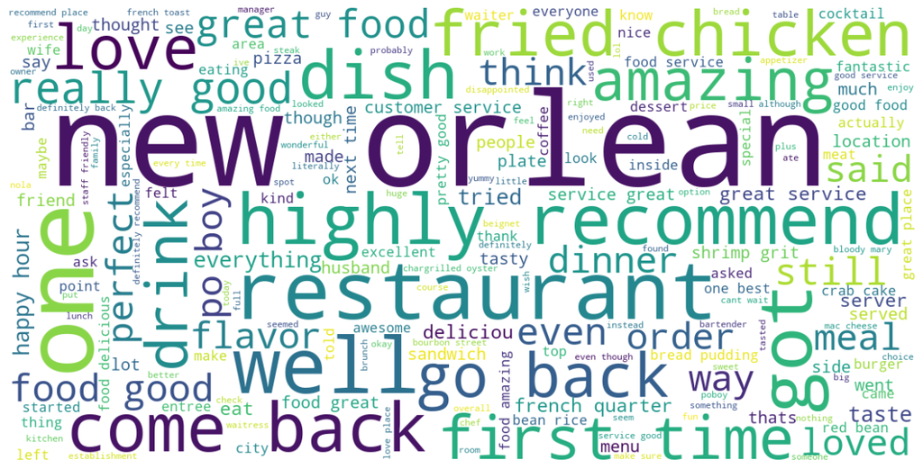

```python
# Step 1: Concatenate all text strings into a single string
text_concatenated = ' '.join(filtered_df['text_cleaned'])

# Step 2: Generate the word cloud
wordcloud = WordCloud(width=1200, height=600, background_color='white').generate(text_concatenated)

# Step 3: Visualize the word cloud
plt.figure(figsize=(15, 9))
plt.imshow(wordcloud, interpolation='bilinear')
plt.axis('off')
plt.show()
```

```python
filtered_df.to_pickle("NO_rest_2019_pres.pkl")
```

```python
restaurant_df.info()
```

```
<class 'pandas.core.frame.DataFrame'>
Index: 476428 entries, 564 to 6990118
Data columns (total 25 columns):
 #   Column             Non-Null Count   Dtype
---  ------             --------------   -----
 0   review_id          476428 non-null  object
 1   user_id            476428 non-null  object
 2   business_id        476428 non-null  object
 3   stars_x            476428 non-null  float64
 4   useful             476428 non-null  int64
 5   funny              476428 non-null  int64
 6   cool               476428 non-null  int64
 7   text               476428 non-null  object
 8   date               476428 non-null  object
 9   total_compliments  476428 non-null  int64
```

[output cut: 17 more lines]

```python
# Creating a dictionary to hold the new column names
rename_dict = {col: col.replace('_y', '_business') for col in restaurant_df.columns if col.endswith('_y')}
rename_dict.update({col: col.replace('_x', '_review') for col in restaurant_df.columns if col.endswith('_x')})

# Renaming the columns using the dictionary
restaurant_df.rename(columns=rename_dict, inplace=True)
merged_df = pd.merge(restaurant_df, user_df, on='user_id', how='inner', suffixes=('', '_user'))
```

```python
merged_df.head().T
```

|  | 0 | 1 | 2 | 3 | 4 |
| --- | --- | --- | --- | --- | --- |
| review_id | Sx8TMOWLNuJBWer-0pcmoA | DK-hGw3XSTJHT26yjzeG3Q | -1qzkGPhIHdmlJgTOb0pNg | EgGMJejqejMMeVM4jZiISg | F5RgL_m7MFL983znFx-t1g |
| user_id | bcjbaE6dDog4jkNY91ncLQ | bcjbaE6dDog4jkNY91ncLQ | bcjbaE6dDog4jkNY91ncLQ | bcjbaE6dDog4jkNY91ncLQ | bcjbaE6dDog4jkNY91ncLQ |
| business_id | e4Vwtrqf-wpJfwesgvdgxQ | e4Vwtrqf-wpJfwesgvdgxQ | pym7c6ZFEtmoH16xN2ApBg | 4WdDY97x4GdMYtyk1KQMnw | q4aAaxdN4wmUZoC6sKEwsw |
| stars_review | 4.0 | 4.0 | 5.0 | 5.0 | 4.0 |
| useful | 1 | 0 | 0 | 0 | 0 |
| funny | 0 | 0 | 0 | 0 | 0 |
| cool | 1 | 0 | 0 | 0 | 0 |
| text | Cute interior and owner (?) gave us tour of up... | Cute interior and owner (?) gave us tour of up... | Amazing food. Only my third time to go and don... | Great find by a friend in the mood for some in... | Skeptical going in but BF wanted to go. Bread ... |
| date | 2017-01-14 20:54:15 | 2018-07-28 20:39:45 | 2019-04-15 21:59:17 | 2014-04-15 18:40:23 | 2018-02-04 03:28:11 |
| total_compliments | 2 | 0 | 0 | 0 | 0 |
| Date | 2017-01-14 00:00:00 | 2018-07-28 00:00:00 | 2019-04-15 00:00:00 | 2014-04-15 00:00:00 | 2018-02-04 00:00:00 |
| Time | 20:54:15 | 20:39:45 | 21:59:17 | 18:40:23 | 03:28:11 |
| name | Melt | Melt | Katie's Restaurant & Bar | Lilly's Cafe | Carrollton Market |
| address | 2549 Banks St | 2549 Banks St | 3701 Iberville St | 1813 Magazine St | 8132 Hampson St |
| city | New Orleans | New Orleans | New Orleans | New Orleans | New Orleans |
| state | LA | LA | LA | LA | LA |
| postal_code | 70119 | 70119 | 70119 | 70130 | 70118 |
| latitude | 29.962102 | 29.962102 | 29.973094 | 29.932123 | 29.944307 |
| longitude | -90.087958 | -90.087958 | -90.095914 | -90.073505 | -90.134325 |
| stars_business | 4.0 | 4.0 | 4.5 | 4.5 | 4.5 |
| review_count | 32 | 32 | 1289 | 777 | 192 |
| is_open | 0 | 0 | 1 | 1 | 0 |
| attributes | {'BusinessParking': '{'garage': False, 'street... | {'BusinessParking': '{'garage': False, 'street... | {'RestaurantsGoodForGroups': 'True', 'Alcohol'... | {'RestaurantsGoodForGroups': 'True', 'GoodForK... | {'RestaurantsTableService': 'True', 'Alcohol':... |
| categories | Sandwiches, Beer, Wine & Spirits, Bars, Food, ... | Sandwiches, Beer, Wine & Spirits, Bars, Food, ... | Restaurants, Bars, Nightlife, American (Tradit... | Cafes, American (Traditional), Vietnamese, Res... | Cocktail Bars, Cajun/Creole, Seafood, Bars, Re... |
| hours | {'Monday': '0:0-0:0', 'Friday': '11:0-17:0', '... | {'Monday': '0:0-0:0', 'Friday': '11:0-17:0', '... | {'Monday': '11:0-21:0', 'Tuesday': '11:0-21:0'... | {'Monday': '0:0-0:0', 'Tuesday': '11:0-21:0', ... | {'Tuesday': '17:0-22:0', 'Wednesday': '17:0-22... |
| name_user | Sophia | Sophia | Sophia | Sophia | Sophia |
| review_count_user | 126 | 126 | 126 | 126 | 126 |
| yelping_since | 2008-04-17 13:39:54 | 2008-04-17 13:39:54 | 2008-04-17 13:39:54 | 2008-04-17 13:39:54 | 2008-04-17 13:39:54 |
| useful_user | 74 | 74 | 74 | 74 | 74 |
| funny_user | 20 | 20 | 20 | 20 | 20 |
| cool_user | 12 | 12 | 12 | 12 | 12 |
| elite |  |  |  |  |  |
| friends | None | None | None | None | None |
| fans | 0 | 0 | 0 | 0 | 0 |
| average_stars | 2.97 | 2.97 | 2.97 | 2.97 | 2.97 |
| compliment_hot | 0 | 0 | 0 | 0 | 0 |
| compliment_more | 0 | 0 | 0 | 0 | 0 |
| compliment_profile | 0 | 0 | 0 | 0 | 0 |
| compliment_cute | 0 | 0 | 0 | 0 | 0 |
| compliment_list | 0 | 0 | 0 | 0 | 0 |
| compliment_note | 0 | 0 | 0 | 0 | 0 |
| compliment_plain | 1 | 1 | 1 | 1 | 1 |
| compliment_cool | 0 | 0 | 0 | 0 | 0 |
| compliment_funny | 0 | 0 | 0 | 0 | 0 |
| compliment_writer | 2 | 2 | 2 | 2 | 2 |
| compliment_photos | 1 | 1 | 1 | 1 | 1 |

```python
merged_df[['address', 'city', 'name']].head()
```

|  | address | city | name |
| --- | --- | --- | --- |
| 0 | 2549 Banks St | New Orleans | Melt |
| 1 | 2549 Banks St | New Orleans | Melt |
| 2 | 3701 Iberville St | New Orleans | Katie's Restaurant & Bar |
| 3 | 1813 Magazine St | New Orleans | Lilly's Cafe |
| 4 | 8132 Hampson St | New Orleans | Carrollton Market |

```python
merged_df = merged_df.rename(columns={"name": "name_business", "average_stars": "average_stars_user", "review_count": "review_count_business", "stars_business":"average_stars_business"})
```

```python
item_df = merged_df[['review_id', 'user_id', 'business_id', 'name_business', 'name_user', 'review_count_business', 'review_count_user', 'average_stars_user', 'average_stars_business', 'stars_review']]
```

```python
item_df = item_df.groupby(['user_id', 'business_id'], as_index=False).agg({
    'review_id': 'first',
    'name_business': 'first',
    'name_user': 'first',
    'review_count_business': 'first',
    'review_count_user': 'first',
    'average_stars_user': 'first',
    'average_stars_business': 'first',
    'stars_review': 'mean'
})
```

```python
item_df.to_pickle("item_df.pkl")
```

```python
item_cats_df = merged_df[['review_id', 'user_id', 'business_id', 'name_business', 'name_user', 'review_count_business', 'review_count_user', 'average_stars_user', 'average_stars_business', 'stars_review', 'categories', 'attributes']]
item_cats_df = item_cats_df.groupby(['user_id', 'business_id'], as_index=False).agg({
    'review_id': 'first',
    'name_business': 'first',
    'name_user': 'first',
    'review_count_business': 'first',
    'review_count_user': 'first',
    'average_stars_user': 'first',
    'average_stars_business': 'first',
    'stars_review': 'mean',
    'categories': 'first',
    'attributes': 'first'
})
```

```python
item_cats_df.to_pickle("items_enhanced_df.pkl")
```

```python
item_df = pd.read_pickle("item_df.pkl")
item_df.info()
```

```
<class 'pandas.core.frame.DataFrame'>
RangeIndex: 466007 entries, 0 to 466006
Data columns (total 10 columns):
 #   Column                  Non-Null Count   Dtype
---  ------                  --------------   -----
 0   user_id                 466007 non-null  object
 1   business_id             466007 non-null  object
 2   review_id               466007 non-null  object
 3   name_business           466007 non-null  object
 4   name_user               466007 non-null  object
 5   review_count_business   466007 non-null  int64
 6   review_count_user       466007 non-null  int64
 7   average_stars_user      466007 non-null  float64
 8   average_stars_business  466007 non-null  float64
 9   stars_review            466007 non-null  float64
dtypes: float64(3), int64(2), object(5)
memory usage: 35.6+ MB
```

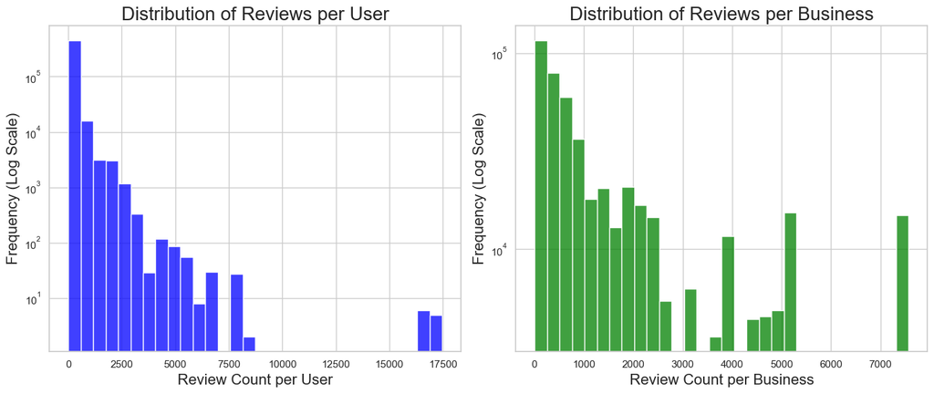

```python
sns.set(style="whitegrid")

fig, axes = plt.subplots(1, 2, figsize=(14, 6))  # 1 row, 2 columns

# Histogram for Reviews per User
sns.histplot(data=item_df, x='review_count_user', bins=30, ax=axes[0], color='blue', log_scale=(False, True))
axes[0].set_title('Distribution of Reviews per User', fontsize=20)
axes[0].set_xlabel('Review Count per User', fontsize=16)
axes[0].set_ylabel('Frequency (Log Scale)', fontsize=16)

# Histogram for Reviews per Business
sns.histplot(data=item_df, x='review_count_business', bins=30, ax=axes[1], color='green', log_scale=(False, True))
axes[1].set_title('Distribution of Reviews per Business', fontsize=20)
axes[1].set_xlabel('Review Count per Business', fontsize=16)
axes[1].set_ylabel('Frequency (Log Scale)', fontsize=16)

# Display the plot
plt.tight_layout()
plt.show()
```

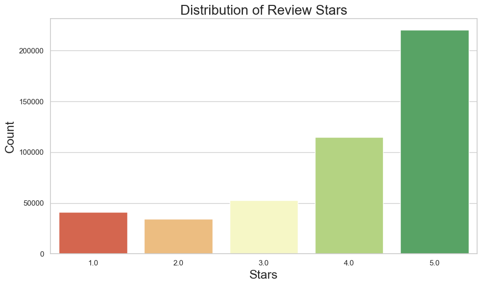

```python
review_stars = item_df['stars_review'].value_counts()
# Reorder the index from 1 to 5
review_stars_ordered = review_stars.reindex(index=[1.0, 2.0, 3.0, 4.0, 5.0])


review_stars_df = pd.DataFrame({'Stars': review_stars_ordered.index, 'Count': review_stars_ordered.values})

sns.set(style="whitegrid")

colors = sns.color_palette("RdYlGn", len(review_stars_ordered.index))
plt.figure(figsize=(10, 6))
ax = sns.barplot(x='Stars', y='Count', data=review_stars_df, palette=colors)

ax.set_title('Distribution of Review Stars', fontsize=20)
ax.set_xlabel('Stars', fontsize=18)
ax.set_ylabel('Count', fontsize=18)

plt.tight_layout()

plt.show()
```